# Settlement Severity Index

Sensitivity Analysis

GEU R&D

11 April, 2025

# Sensitivity Analysis

## Missing Values

It is highly suggested to do a distribution of the missing values. The Flag Index counts the number of indicators that go above a defined severity thresholds. One needs to make sure that whatever is not being counted is “not severe” and not missing values.

Therefore, it is important to look at the distribution of missing values.

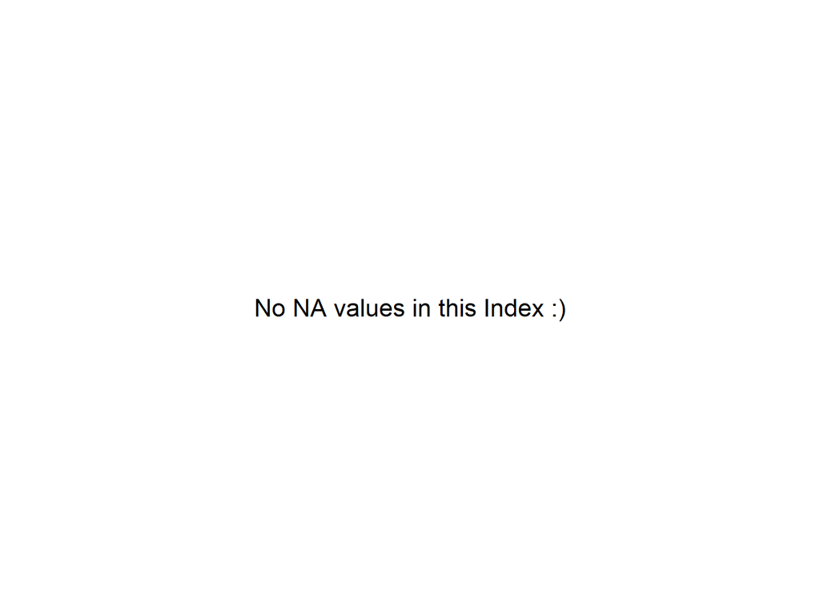

## Severity Frequency

The goal of this section is to look at how often each indicator is above the severity thresholds. The thresholds are 3, 4 and 4+, which is why the bar plot is repeated three times. It is important to look at the overall distribution of each indicator, because an indicator that is very often extremely severe might be due to a wrongly-set threshold. On the contrary, it might also be that the situation is indeed very severe in most of the country. This is why contextual knowledge is key in the definition of the thresholds.

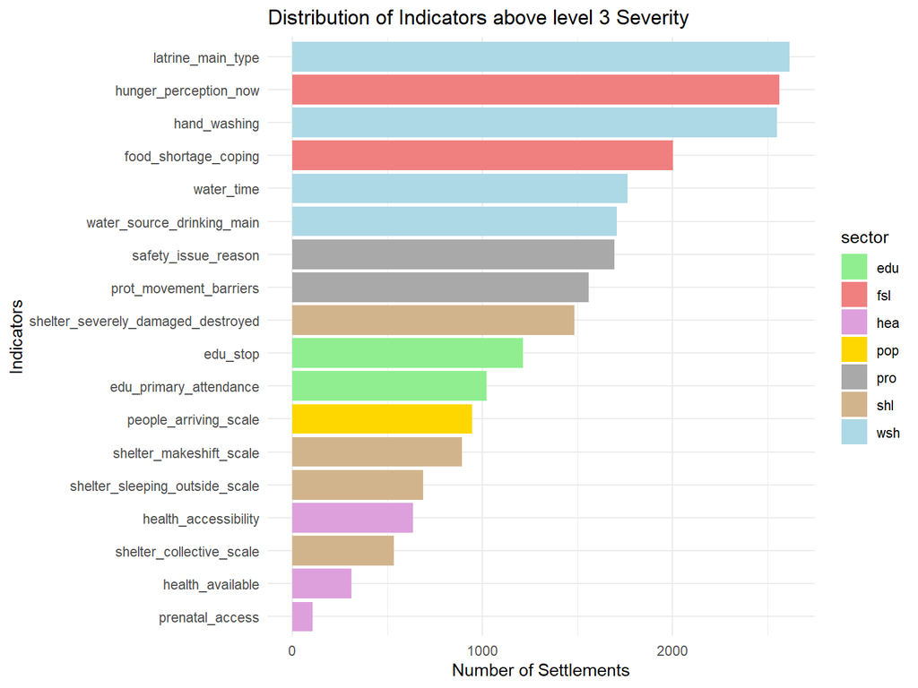

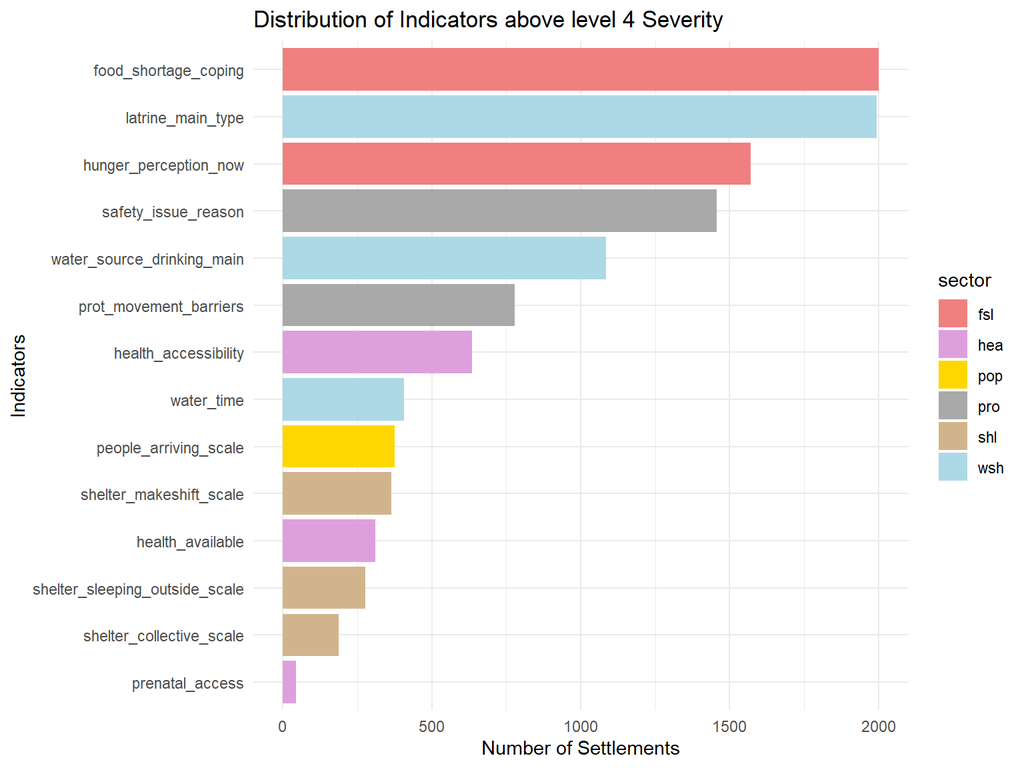

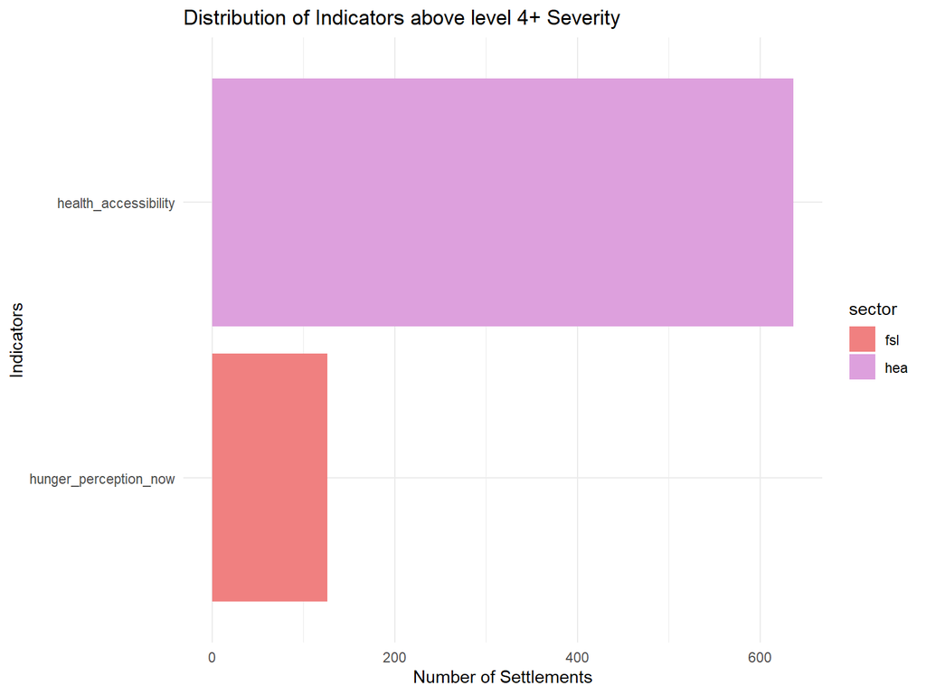

## Distribution

The goal of this section is to look at the distribution of the flag index across settlements. Unlike the previous section where we assessed how often each indicator is above each threshold, in this section we look at the distribution of the flag index across settlements.

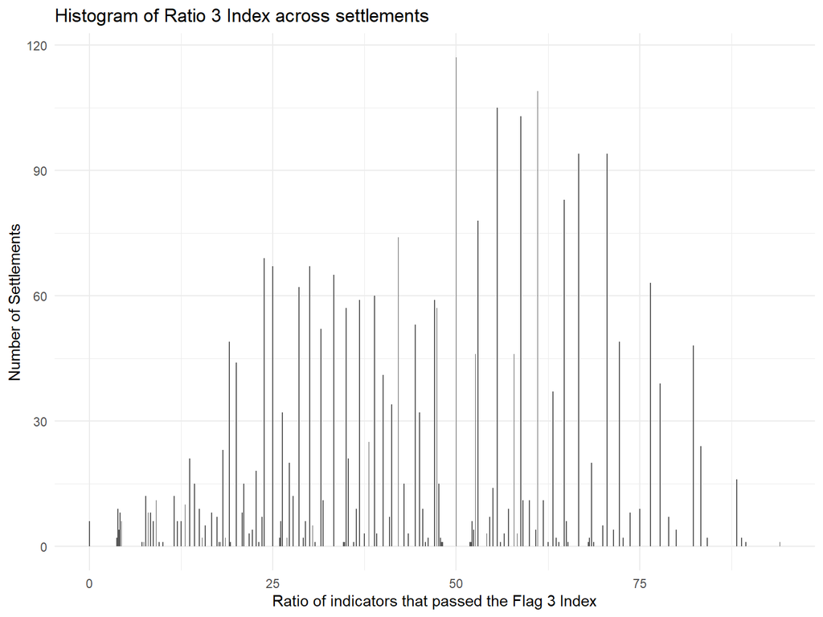

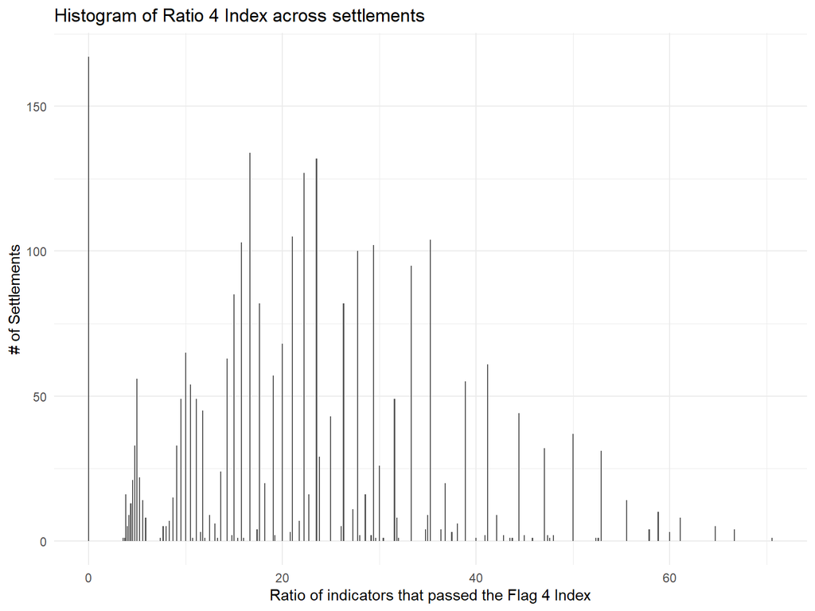

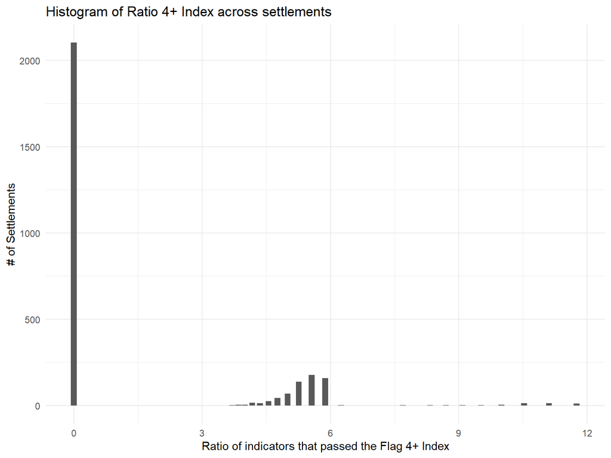

## Sector information

The goal of this section is to look at the maximum number of indicators that are above the severity thresholds per each sector. Please, keep in mind that some sectors cannot go beyond level 3 or 4 of severity.

Each bar plot shows the maximum observed value of the flag index per each sector per each level of severity.

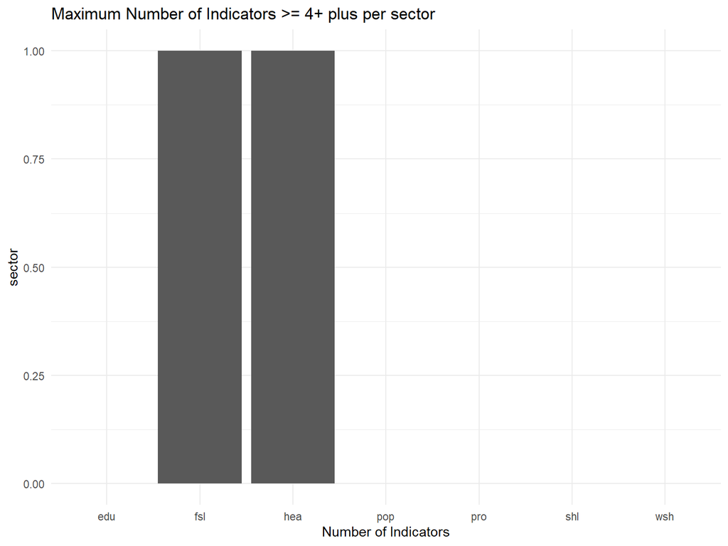

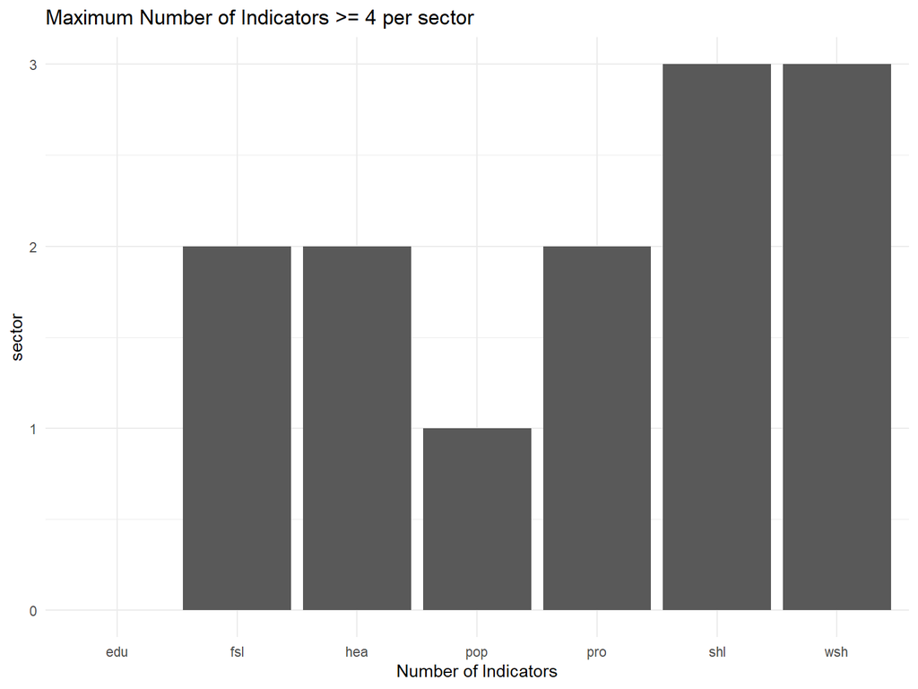

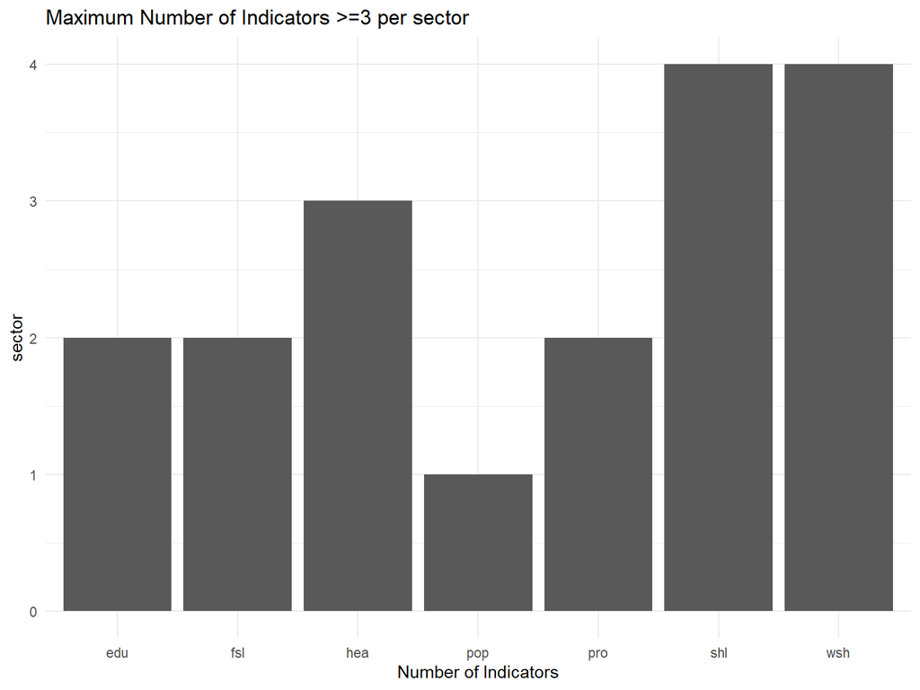

This plots can be interpreted as the maximum number of indicators that can pass the different severity thresholds, in other words, the maximum possible severity of each sector. This information can be useful in the case of normalisation.

## Distributions and Correlations

In this section, we explore the distribution of the indicators, how often each value is picked up by the data. Furthermore, we run correlation matrices across indicators to see the relationship between indicators. To make the analysis more comprehensible, we’ll divide the indicators by sector.

### WASH

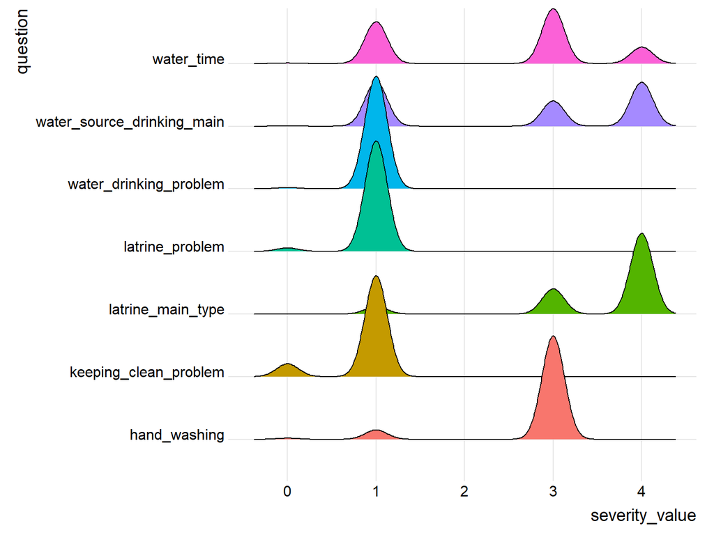

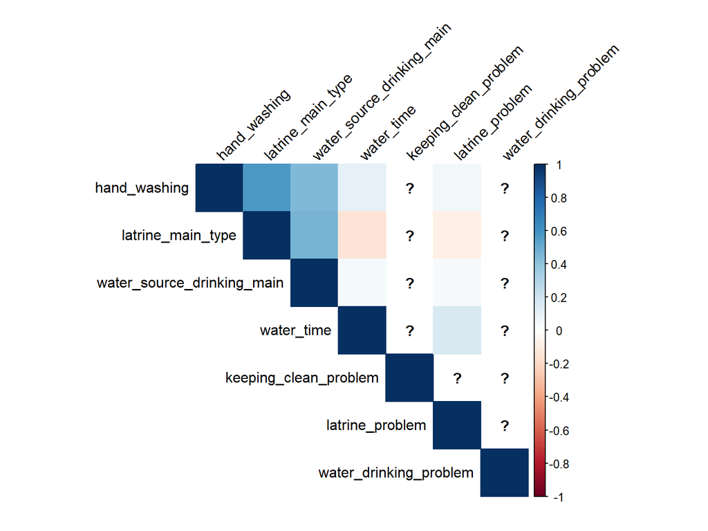

### FSL

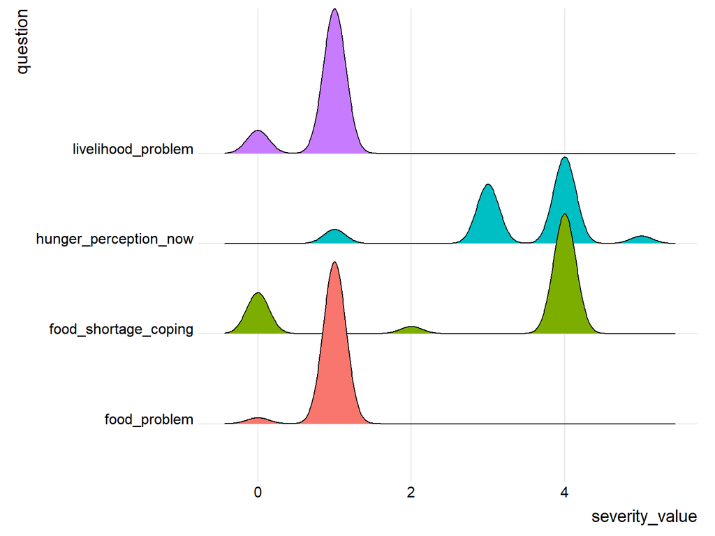

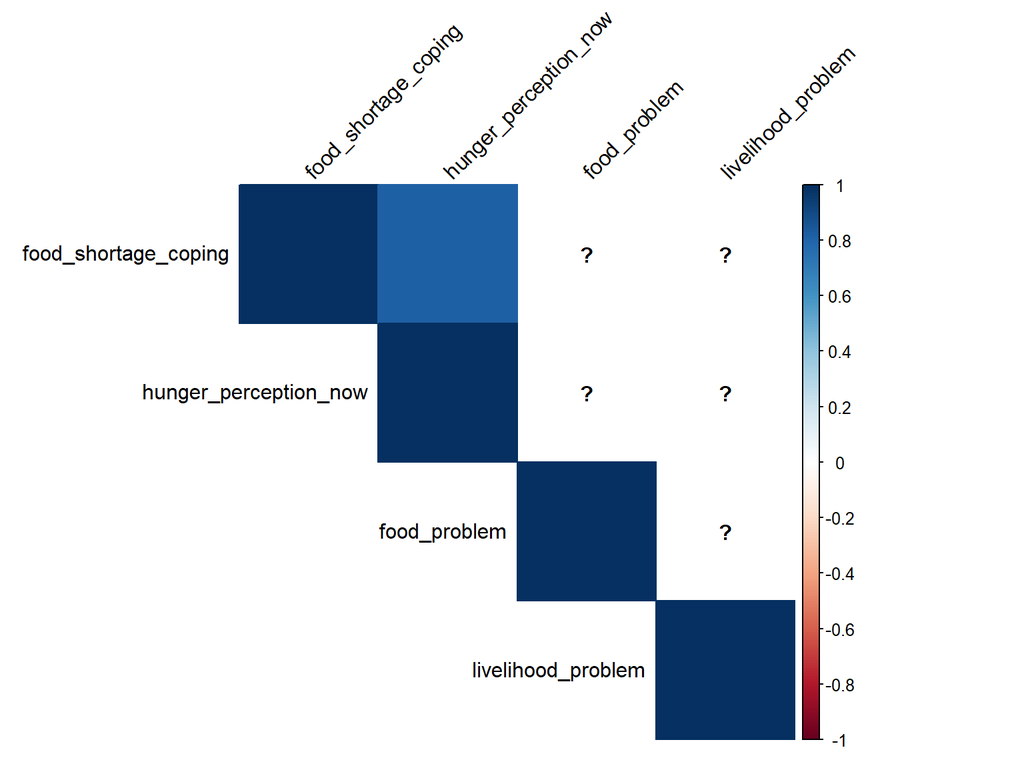

### Health

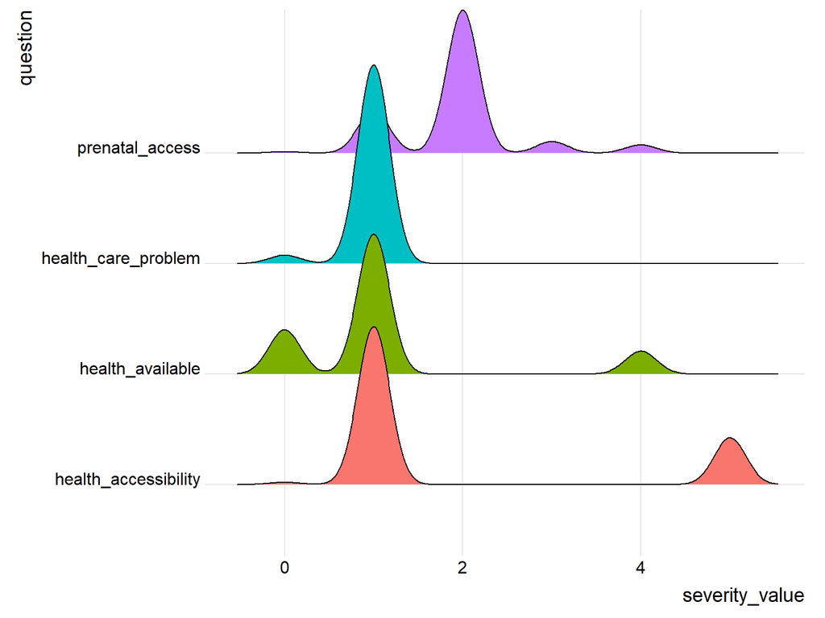

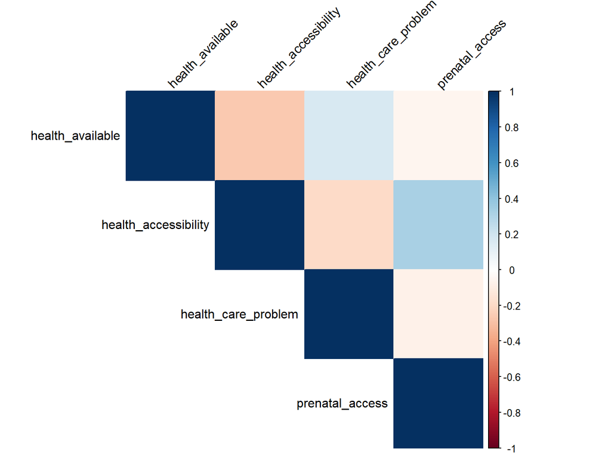

### Shelter

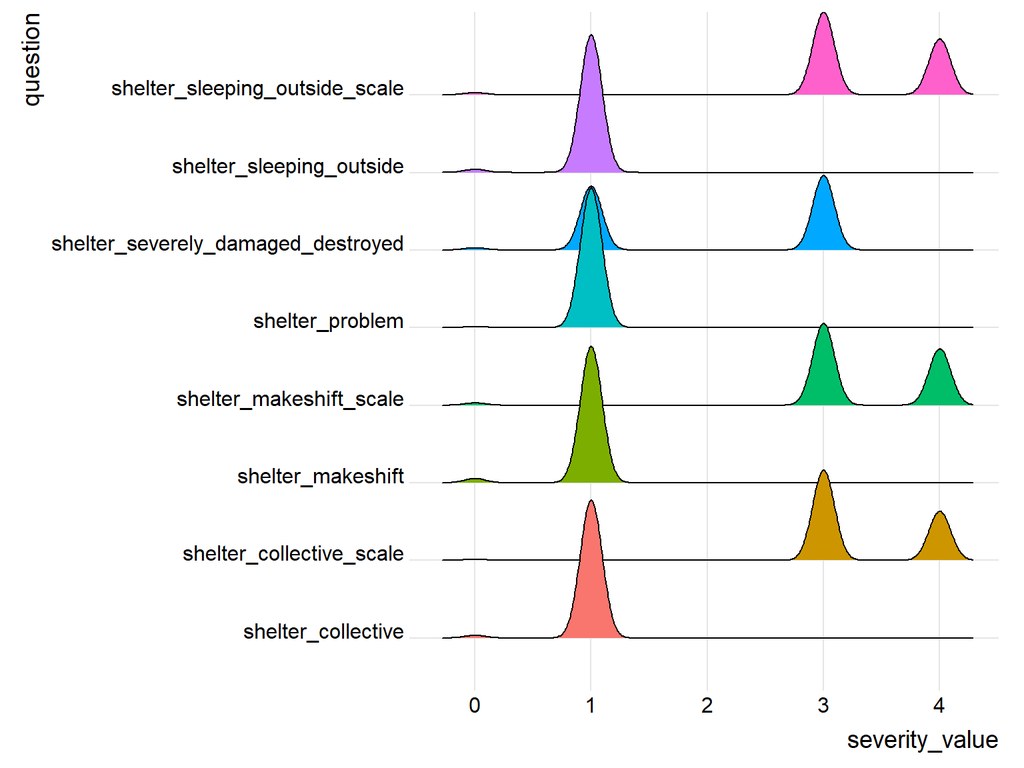

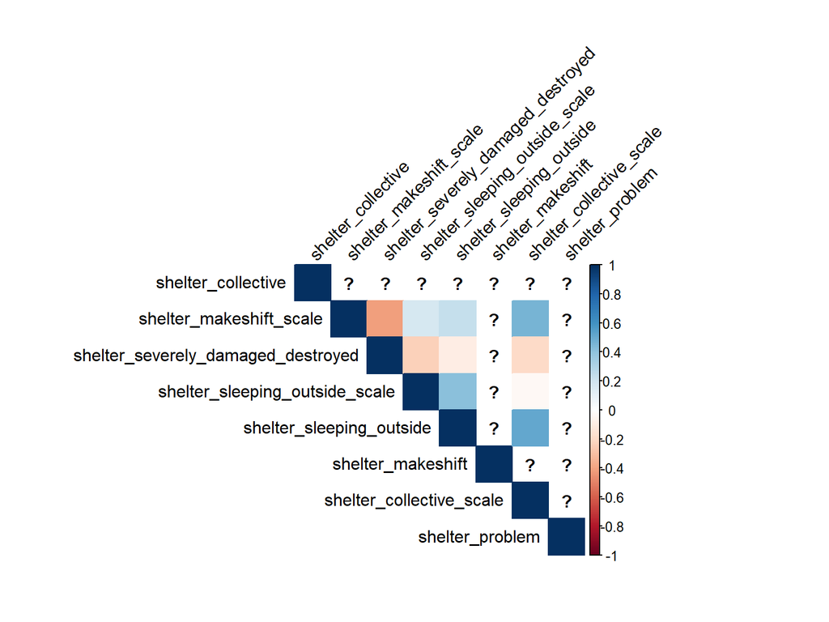

### Protection

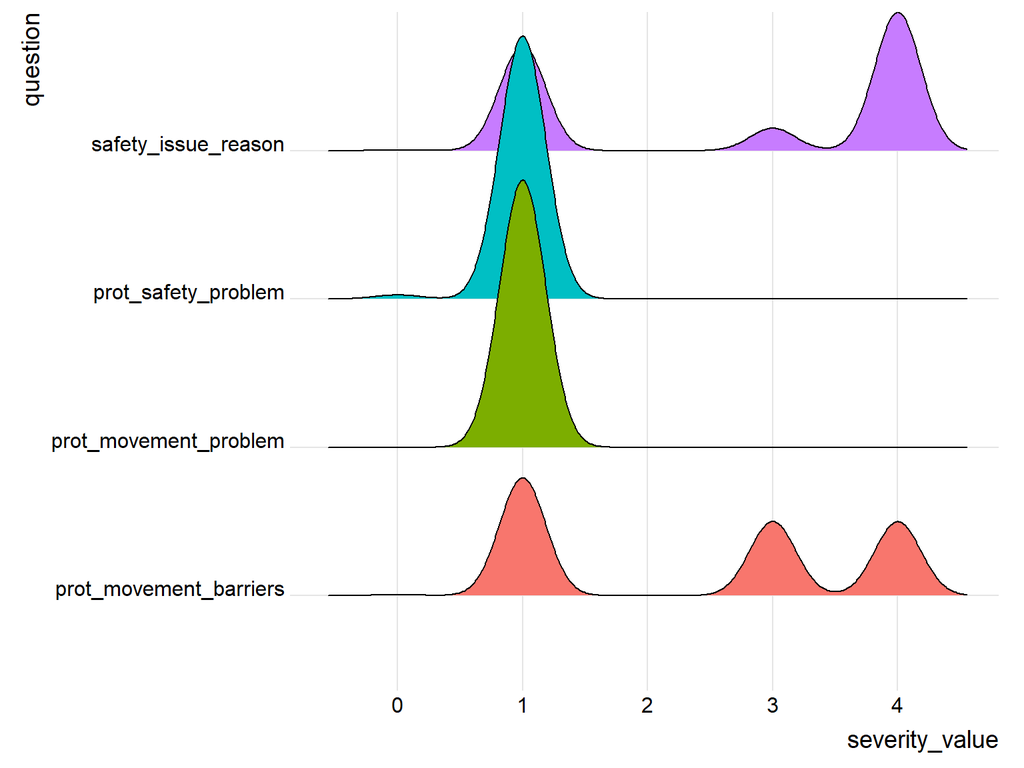

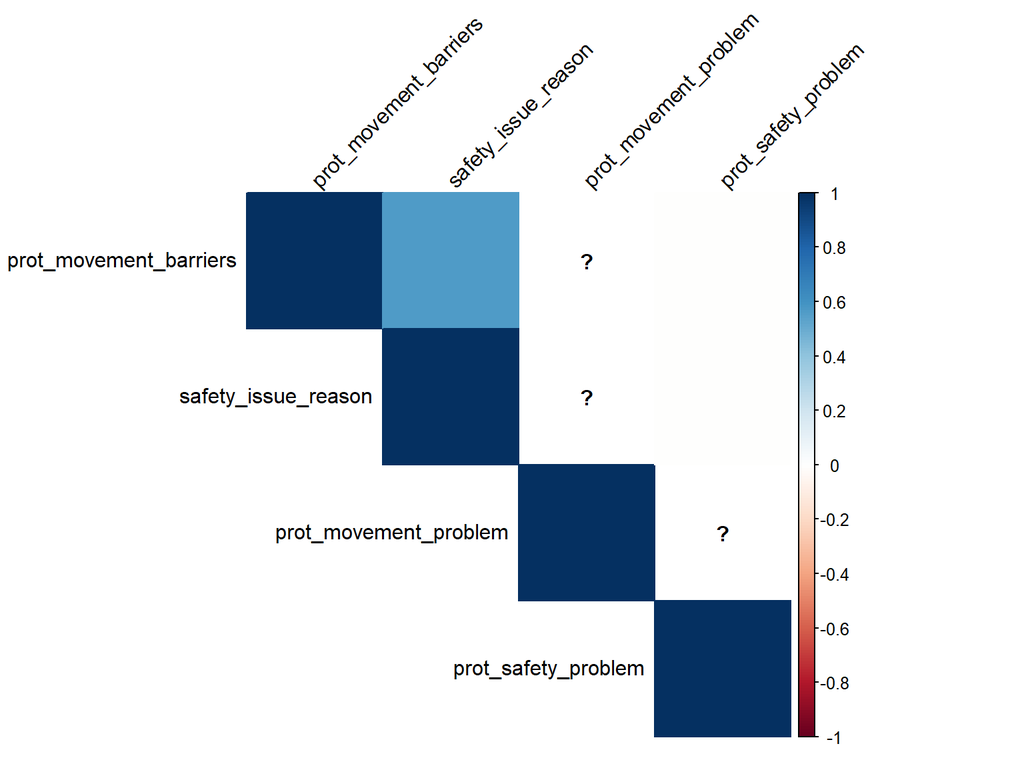

### Education

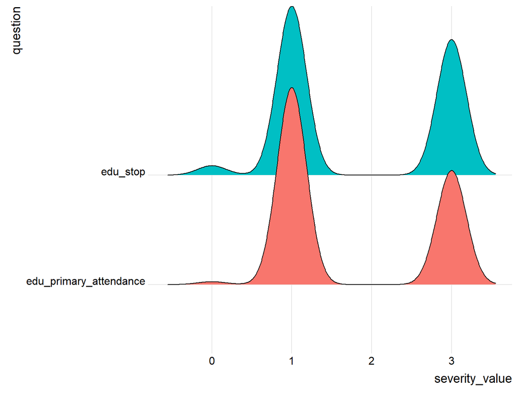

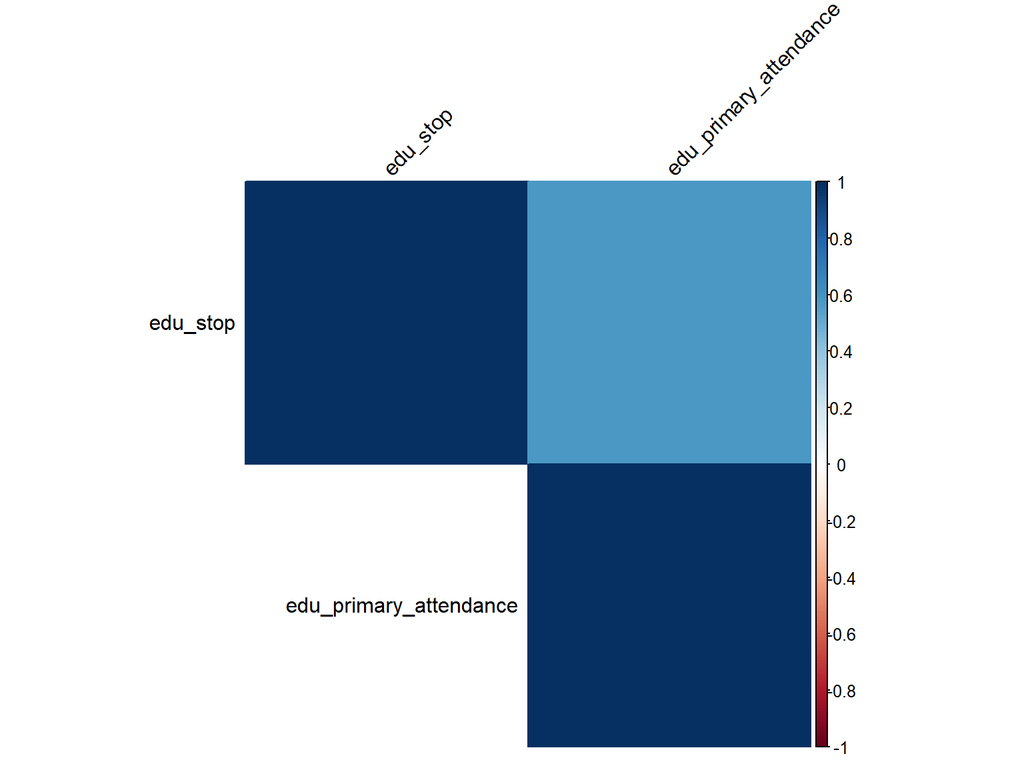

### Population Movement

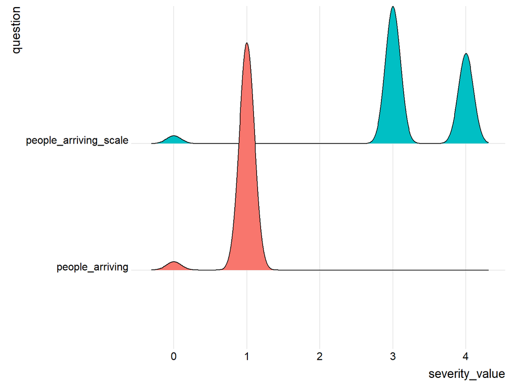

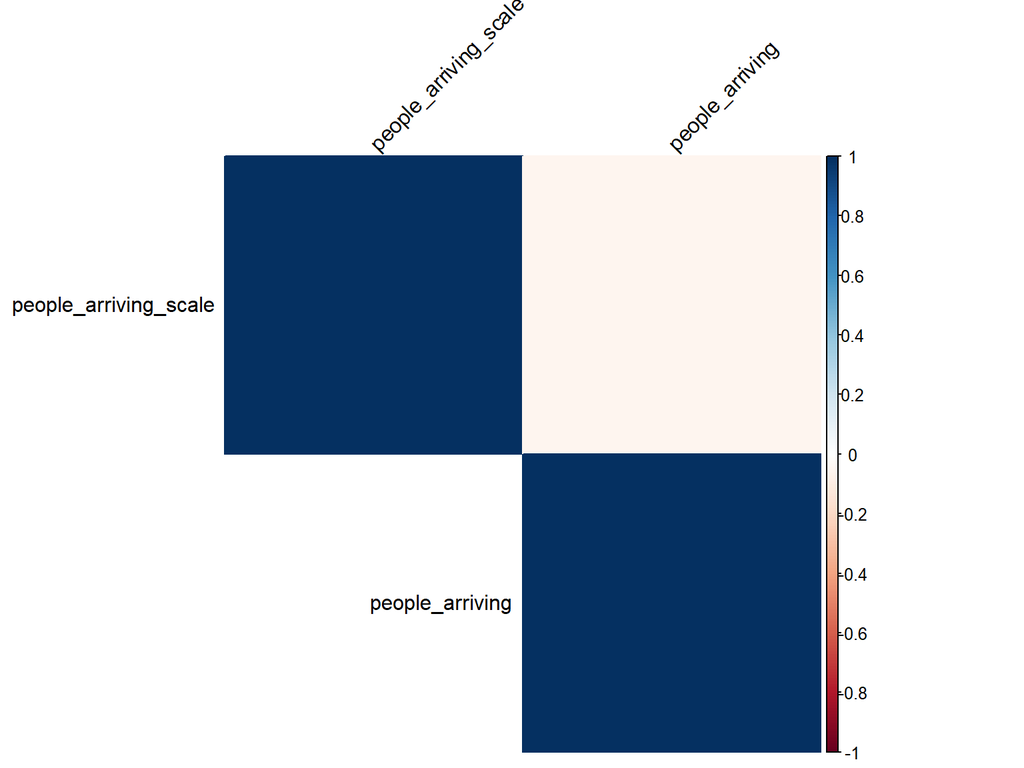

### Cash and Market

[figure not shown]